# Lab6_Poblet

Marcel Poblet

October 27, 2016

This report studies the “Law of Large Numbers”.

### Set Seed

First we set a seed to ensure our data is reproducable. I chose my current Publix store number.

```r
set.seed(519)
```

## Create Random Samples

Use the runif method that retrieves random values from the uniform distribution set with a min and max.

### Sample 1

Generate a sample of size 100 from the uniform distribution between 1 and 10, inclusive.

```r
sample <- runif(100, min = 1, max = 10)
```

### Theoretical Uniform Distribution

Display the first quartile of the theoretical uniform distribution.

```r
qunif(.25, min = 1, max = 10)
```

```
## [1] 3.25
```

### First Quartile of Sample 1

Display the first quartile of the sample you generated. Find the first quartile of the generated sample with quantile, using 0.25 to specifie the first quartile

```r
quantile(sample, .25)
```

```
##      25%
## 3.417356
```

### Histogram of Sample 1

Create a histogram of the sample you generated.

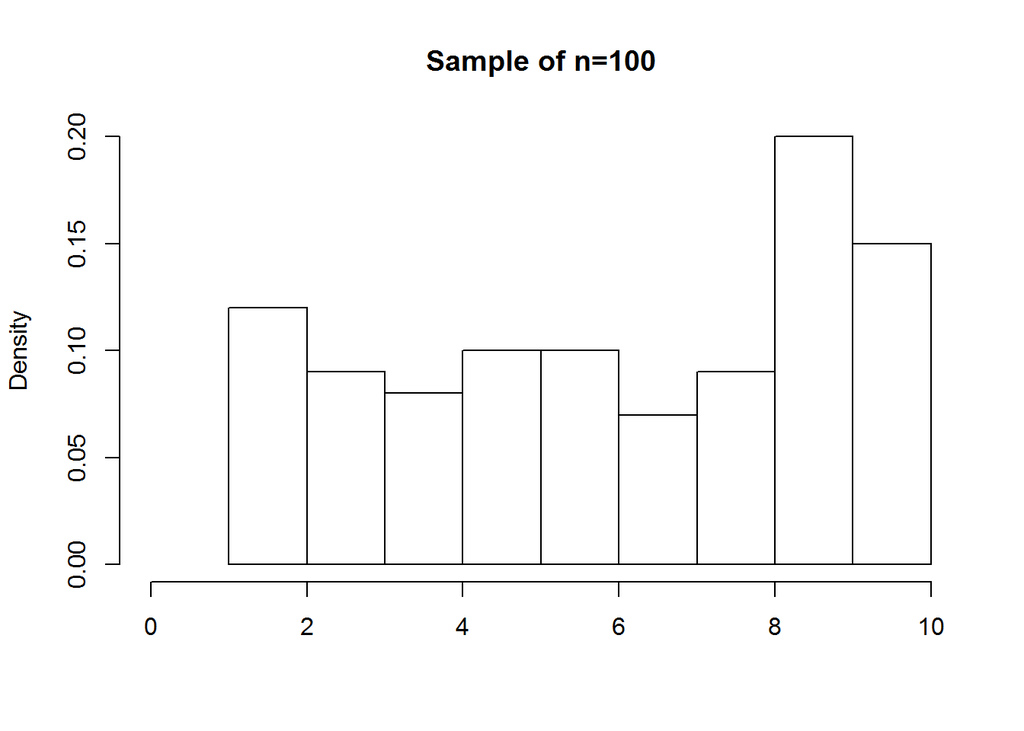

```r
hist(sample,xlim = c(0,10), freq = FALSE, xlab = "", main = "Sample of n=100")
```

### Sample 2

Generate a second sample of size 1000.

```r
sample_Two <- runif(1000, min = 1, max = 10)
```

### First Quartile for Sample 2

Display the first quartile of your second sample.

```r
quantile(sample_Two, .25)
```

```
##      25%
## 3.182823
```

### Histogram of Sample 2

Create a histogram of your second sample.

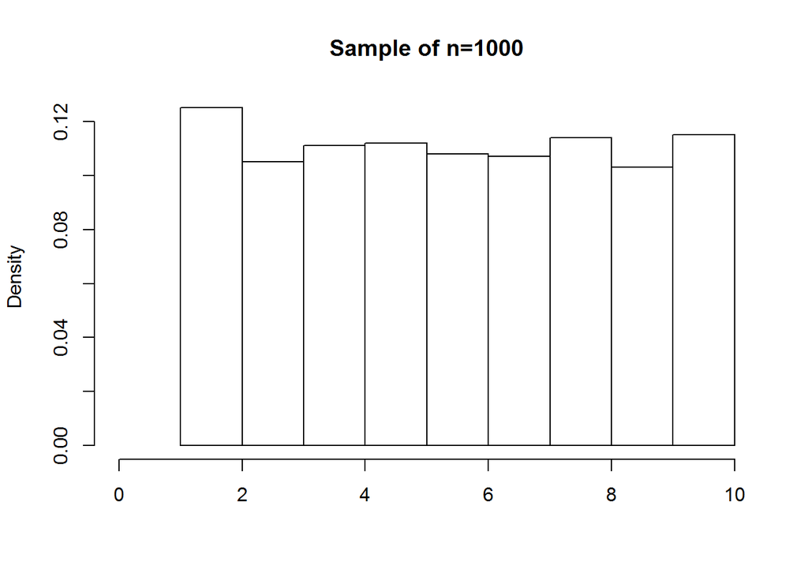

```r
hist(sample_Two, xlim = c(0,10), freq = FALSE, xlab = "", main = "Sample of n=1000")
```

### Sample 3

Generate a third sample of size 10,000.

```r
sample_Three <- runif(10000, min = 1, max = 10)
```

### First Quartile for Sample 3

Display the first quartile of your third sample.

```r
quantile(sample_Three, .25)
```

```
##      25%
## 3.290638
```

### Histogram of Sample 3

Create a histogram of your third sample.

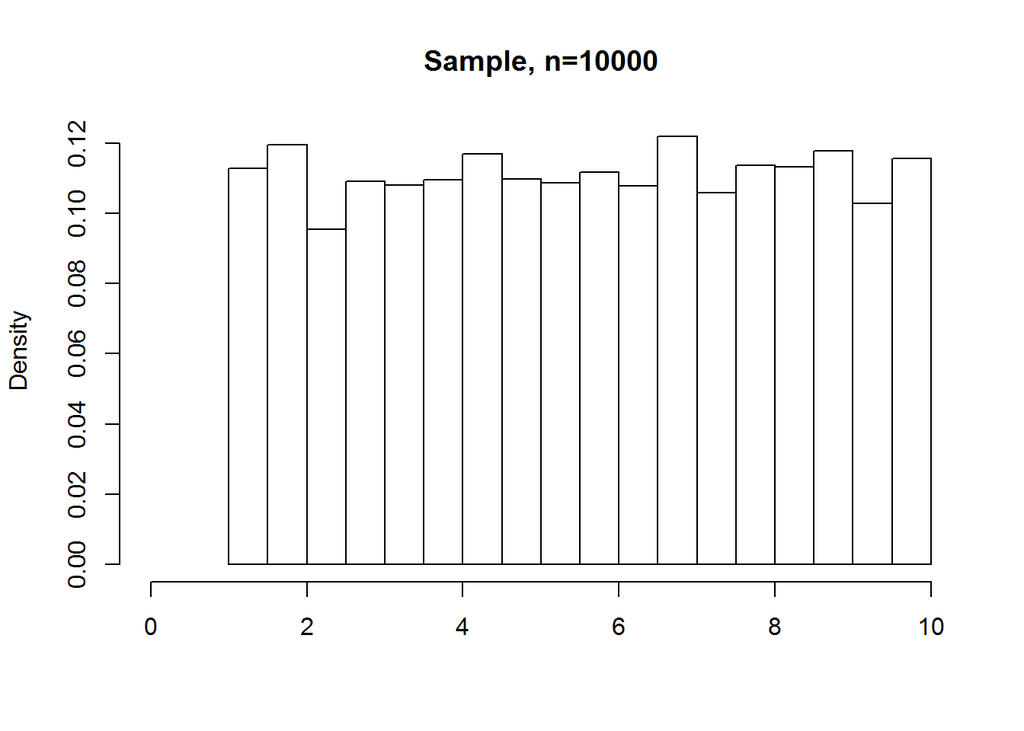

```r
hist(sample_Three,xlim=c(0,10), freq = FALSE, xlab="", main="Sample, n=10000")
```

### Discussion

#### 1st Quartile Comparison

How did the first quartile of your 3 samples compare to each other and to the first quartile of the distribution from which they were drawn?

The samples stayed close in value to eachother, and fluctuated near the theoretical uniform distribution. The larger the sample size, the closer the first quartile came to 3.25

| Sample | 1st Quartile |
| --- | --- |
| 1 | 3.42 |
| 2 | 3.18 |
| 3 | 3.29 |
| Theo. | 3.25 |

The chart displays the fluctuation of the first quratile of each sample in relation to the first quartile of the theoretical distribution. Sample one falls above by a difference of 0.17. Sample two below by 0.07, and sample three falls above by just 0.04.

#### Histogram Comparison

How did the histograms of your 3 samples compare?

As the sample size of each histogram increased, the graphs appeared more uniform.

#### “Law of Large Numbers”

What does this law have to do with the tasks you have completed above?

The “Law of Large Numbers” is what occured on our samples. As our sample size increases, it will converge with the expected value of 3.25 for the first quartile and holds true for the other quartiles aswell.